# Statistiek I - Lab session 3

Robert van Timmmeren (s4535553)

Generated on: Tue Feb 23 21:21:02 2021

# 1 Exercise 1

```r
download.file('http://www.let.rug.nl/wieling/Statistiek-I/dat.rda','dat.rda')
load('dat.rda',verbose=T)
```

```
## Loading objects:
##   dat
```

```r
#Create a variable 'dmgrade' which contains the difference between the English grade and the average English grade
dmgrade <- dat$english_grade - mean(dat$english_grade)

#Create a variable 'admgrade' which contains the absolute value of dmgrade
admgrade <- abs(dmgrade)

#Doing this is also possible with one single command
abs(dat$english_grade - mean(dat$english_grade))
```

```
##   [1] 2.28525896 1.28525896 0.28525896 0.71474104 0.28525896 1.11474104
##   [7] 0.71474104 1.28525896 0.71474104 0.71474104 0.28525896 0.28525896
##  [13] 0.28525896 1.71474104 0.28525896 1.28525896 0.71474104 0.71474104
##  [19] 0.88525896 0.71474104 0.28525896 0.71474104 0.71474104 0.71474104
##  [25] 0.28525896 1.28525896 0.88525896 0.28525896 0.28525896 0.71474104
##  [31] 0.28525896 0.28525896 0.71474104 1.28525896 0.28525896 0.28525896
##  [37] 0.28525896 0.28525896 0.28525896 0.71474104 0.28525896 1.01474104
##  [43] 1.28525896 0.98525896 0.71474104 0.71474104 1.71474104 0.28525896
##  [49] 0.28525896 0.71474104 0.28525896 0.71474104 0.28525896 2.21474104
##  [55] 0.28525896 0.28525896 1.28525896 1.28525896 0.78525896 1.28525896
##  [61] 1.28525896 0.28525896 1.21474104 1.28525896 1.28525896 0.28525896
##  [67] 1.28525896 1.28525896 0.71474104 0.71474104 1.28525896 0.28525896
##  [73] 0.71474104 0.28525896 1.28525896 1.18525896 0.71474104 0.28525896
##  [79] 1.71474104 1.71474104 0.28525896 0.71474104 0.28525896 0.71474104
##  [85] 1.71474104 0.28525896 0.28525896 0.28525896 1.28525896 1.28525896
```

[output cut: 69 more lines]

```r
#It is possible to store all these values in a column in the 'dat' data
dat$admgrade <- abs(dat$english_grade - mean(dat$english_grade))

#We can then also remove it again
dat$admgrade <- NULL

#Calculates the average of admgrade
mean(abs(dat$english_grade - mean(dat$english_grade)))
```

```
## [1] 0.7134236
```

```r
#Calculates the standard deviation of English grades
sd(dat$english_grade)
```

```
## [1] 0.8661878
```

# 2 Exercise 2

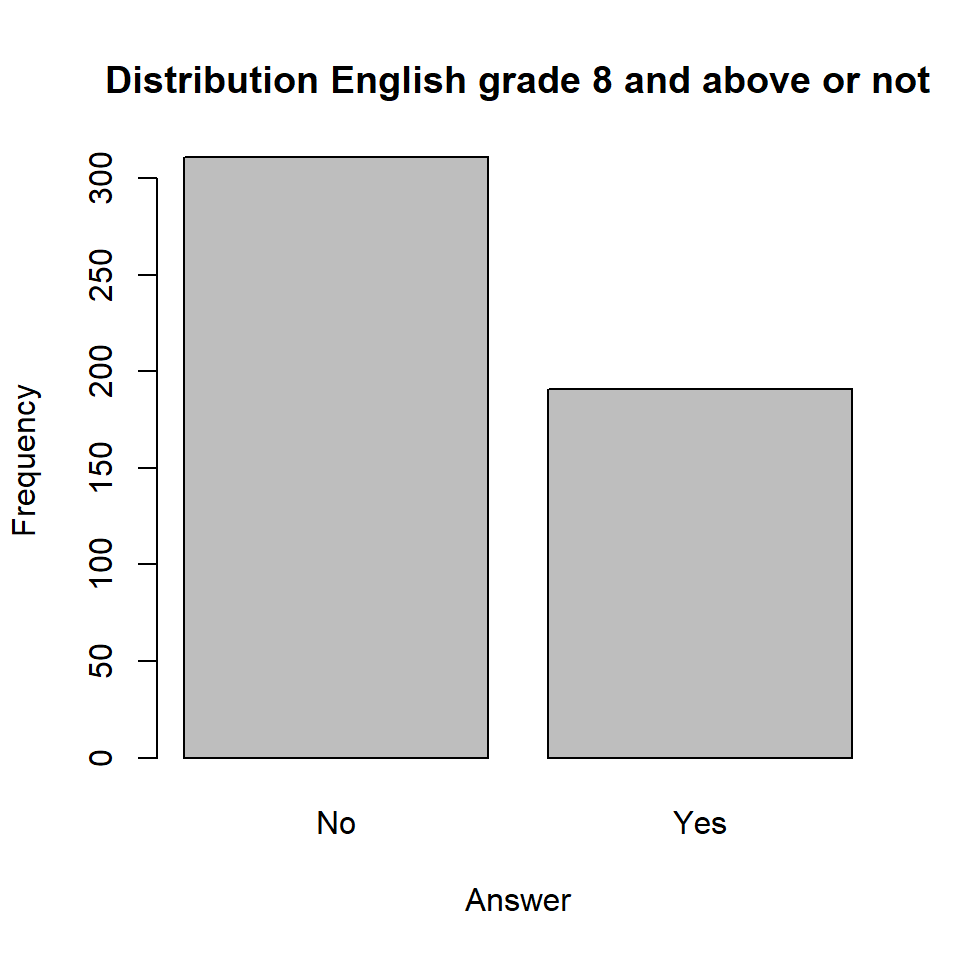

```r
#Creates a column 'english8' in 'dat' which has value Yes for english_grade 8 and higher, and No for grade below 8
dat$english8 = 'Yes'
dat[dat$english_grade < 8, ]$english8 <- 'No'

#Converts the english8 data type to factor with 2 levels 'Yes', 'No'
dat$english8 <- as.factor(dat$english8)

#Creates a bar plot of the frequency's of whether someone had an 8 or higher or not
barplot(table(dat$english8), main = "Distribution English grade 8 and above or not", ylab = "Frequency", xlab = "Answer")
```

# 3 Exercise 3

```r
#Create a new dataset with only people who had an english_grade of 8 and above
dat2 <- dat[dat$english8 == 'Yes', ]

#Show the number of rows this new dataset contains
nrow(dat2)
```

```
## [1] 191
```

```r
#Saves this new dataset as 'dat2.rda'
save(dat2, file = 'dat2.rda')
```

# 4 Exercise 4

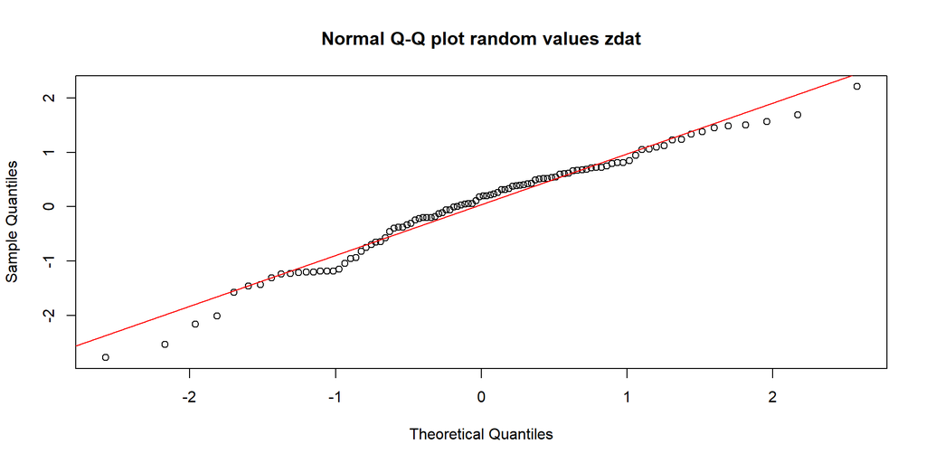

```r
#Generates 100 random values with mean 0 and standard deviation 1 and store it in variable 'zdat'
set.seed(222)
zdat <- rnorm(100, mean = 0, sd = 1)

#Verifying that values in zdat are (close to) normal
#With a q-q plot:
qqnorm((zdat), main = "Normal Q-Q plot random values zdat")
qqline(zdat, col = 'red')
```

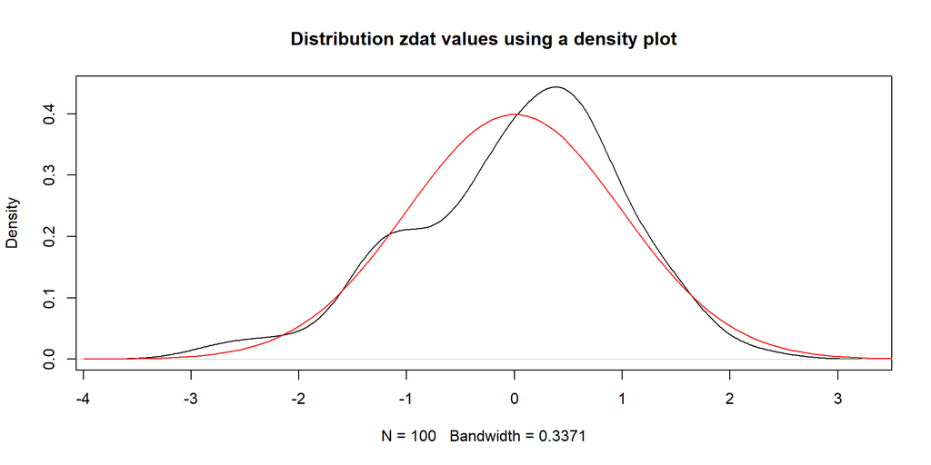

```r
#and with the distribution of the values in a plot:
plot(density(zdat), main = "Distribution zdat values using a density plot")

#This draws a perfect normal distribution line over the diagram
lines(seq(-4, 4, length = 100), dnorm(seq(-4, 4, length = 100)), col = "red")
```

# 5 Exercise 5

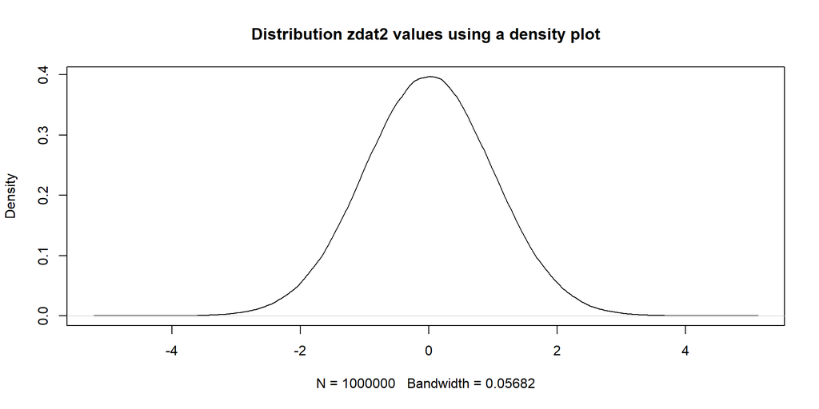

```r
#Generate 1000000 random values with mean 0 and standard deviation 1 and store it in variable 'zdat2'
zdat2 <- rnorm(1000000, mean = 0, sd = 1)
plot(density(zdat2), main = "Distribution zdat2 values using a density plot")
```

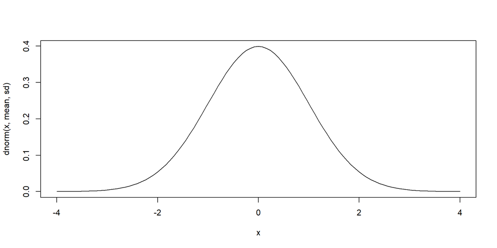

```r
#Create a function to draw a perfect standard normal distribution
plotNormal <- function(mean=0, sd=1) {
    curve( dnorm(x,mean,sd), xlim=c(mean-4*sd,mean+4*sd) )
}

#Call this function
plotNormal()
```

# 6 Exercise 6

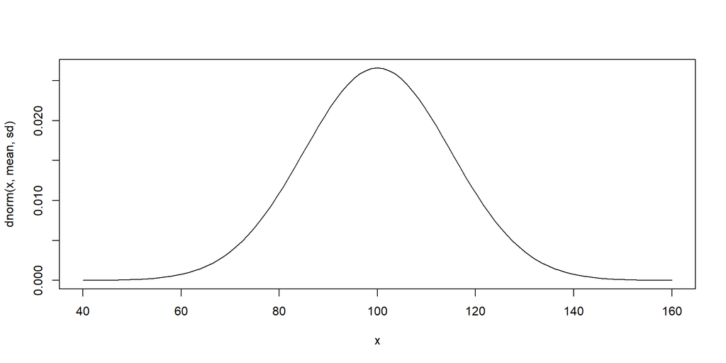

```r
#Use the function to draw the normal distribution with mean 100 and standard deviation 15
plotNormal(mean=100, sd=15)
```

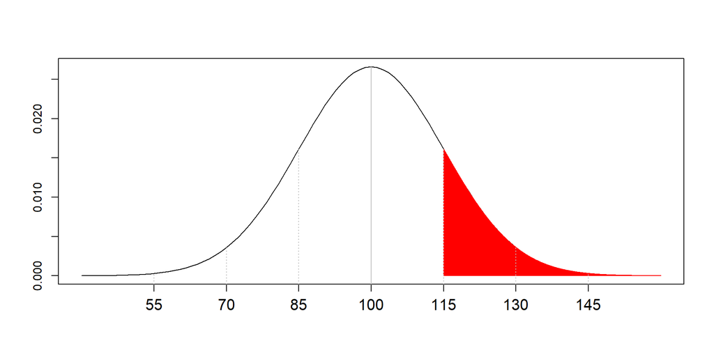

```r
#Create an improved version of plotNormal
plotNormal <- function(mean=0, sd=1, shademin=NA, shademax=NA, twotailed=F, shadecol='red') {
    # plots normal distribution
    curve(dnorm(x,mean,sd),xlim=c(mean-4*sd,mean+4*sd),xlab='',ylab='',xaxt='n')

    if (!(is.na(shademin) & is.na(shademax))) { # if shademin and/or shademax are set
        # draw shaded area
        if (is.na(shademin)) { shademin <- mean - 4*sd } # default shademin: left side of plot
        if (is.na(shademax)) { shademax <- mean + 4*sd } # default shademax: right side of plot
        polygon(c(shademin,seq(shademin,shademax,0.01),shademax),
                c(0,dnorm(seq(shademin,shademax,0.01),mean,sd),0),col=shadecol, border=shadecol)
    }

    # x-axis labels and vertical lines at sd's
    axis(1, at=seq(mean-3*sd,mean+3*sd,by=sd), cex.axis=1.3,
         labels=round(seq(mean-3*sd,mean+3*sd,by=sd),1))
    for (i in c(-3,-2,-1,0,1,2,3)) {
       segments(mean+i*sd,par("usr")[3],mean+i*sd,dnorm(mean=mean,sd=sd,mean+sd*i),
                lty=ifelse(i==0,1,3),col='gray')
    }
}

#Use the improved function to draw the normal distribution of IQ score with the probability drawn of at least an IQ of 115
plotNormal(mean=100, sd=15, shademin=115)
```

```r
#Calculate the z-score of 115 and store it in variable 'z'
z <- (115-100)/15

#Calculate the probability of an IQ score >= 115 using pnorm()
pnorm(z, lower.tail=FALSE)
```

```
## [1] 0.1586553
```

```r
#Calculate the probability of an IQ score >= 115 using pnorm() without z-score first
pnorm(115, mean=100, sd=15, lower.tail=FALSE)
```

```
## [1] 0.1586553
```

# 7 Exercise 7

```r
#95% confidence interval
#1. Calculate the standard error
se <- 15/sqrt(25)

#2. This is the lower bound
105-2*se
```

```
## [1] 99
```

```r
#3. This is the upper bound
105+2*se
```

```
## [1] 111
```

The 95% confidence interval of the sample mean means that 95% of the sample means lie within -2 up to +2 standard error of the population mean. So there is a 95% chance that the sample mean lies within the range of -2 up to +2 standard error of the population mean. How far it’s off the population mean depends on the standard error.

```r
#99% confidence interval
#1. Calculate the standard error
se <- 15/sqrt(25)

#2. This is the lower bound
105-2.6*se
```

```
## [1] 97.2
```

```r
#3. This is the upper bound
105+2.6*se
```

```
## [1] 112.8
```

# 8 Exercise 8

Null hypothesis: The mean IQ of people in Groningen is the same as the population mean (100) Alternative hypothesis: The mean IQ of people in Groningen is higher than the population mean (100)

We should use a one-tailed test, because we only want to assess whether if it a higher IQ than the population. This means we only want to look at one tail (the right side).

```r
#1. Convert the sample mean to z-score (use standard error)
sigma <- 15
mu <- 100
m <- 105
n <- 25
(se <- sigma/sqrt(n))
```

```
## [1] 3
```

```r
(zval <- (m - mu) /se)
```

```
## [1] 1.666667
```

```r
#2. Calculate the p-value
pnorm(zval, lower.tail = FALSE)
```

```
## [1] 0.04779035
```

```r
#3. Compare the p-value with the a-value
```

p-value is 0.04779035, whereas a-value is 0.05. The difference is significant, because the p-value is <= than the a-value. This means we do reject the null hypothesis, because there is strong evidence against the null hypothesis. This means we assume the alternative hypothesis is true.

We use standard error when converting the sample mean to z-score.

```r
#Critical z-value
qnorm(p=0.05, mean=100, sd=se, lower.tail=F)
```

```
## [1] 104.9346
```

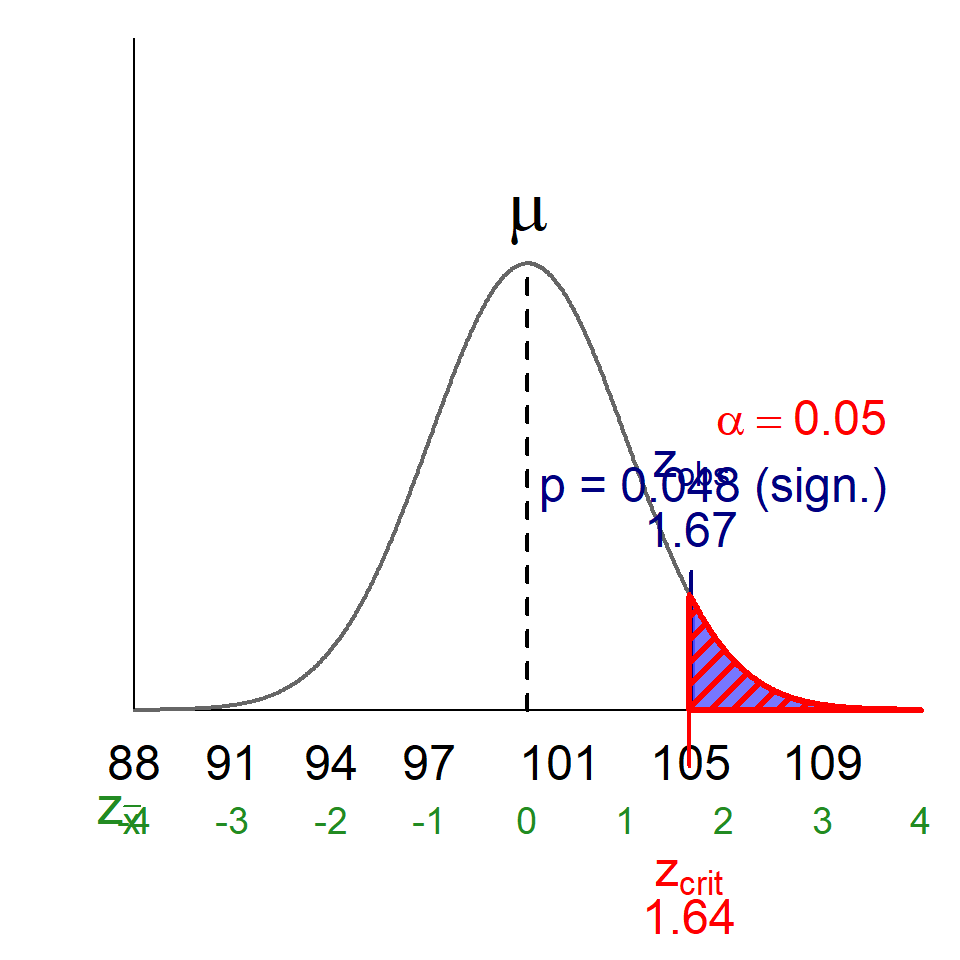

```r
#Prepare visualizations
download.file('http://www.let.rug.nl/wieling/Statistiek-I/zvis.R','zvis.R') # downloads file
source('zvis.R') # loads function, so you can use it in R

#Visualizing the IQ example we conducted
zvis(105, mu, sigma, n, "right")
```

# 9 Exercise 9

```r
#What was the hypotheses if question was whether or not IQ was significantly different from the population?
```

Null hypothesis: The mean IQ of people in Groningen is the same as the population mean (100) Alternative hypothesis: The mean IQ of people in Groningen is not equal to the population mean (100)

To test this hypothesis we would use a two-sided z-test.

```r
#Calculate p-value for two-sided z-test with pnorm
pnorm(105, mean=100, sd=se)
```

```
## [1] 0.9522096
```

```r
#Critical z-value for two-sided z-test
qnorm(p=0.025, mean=100, sd=se)
```

```
## [1] 94.12011
```

```r
#The effect size is the difference between m (105) and u (100) divided by the standard deviation of the sample group
(105-100)/15
```

```
## [1] 0.3333333
```

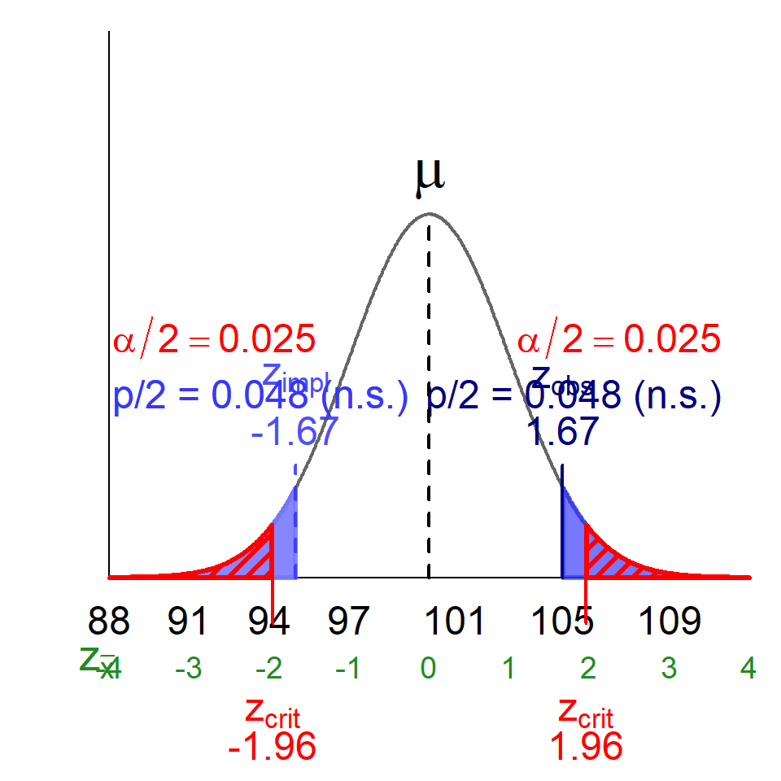

```r
#Visualizing the two-sided example
zvis(105, 100, 15, 25)
```

# 10 Exercise 10

```r
#State hypotheses:
```

Null hypothesis: The mean Dutch proficiency test score of people living in Groningen is equal to the population mean (7) Alternative hypothesis: The mean Dutch proficiency test score of people living in Groningen is lower than the population mean (7)

To test this we use a one-tailed significance test, because we want to check the left side.

```r
#Standard error
(se <- 2/sqrt(64))
```

```
## [1] 0.25
```

```r
#z-value
(zscore <- ((6.5-7) / se))
```

```
## [1] -2
```

```r
#p-value
(pval <- pnorm(zval, lower.tail = T))
```

```
## [1] 0.9522096
```

```r
#critical value
qnorm(p=0.05, mean=7, sd=se)
```

```
## [1] 6.588787
```

Since 6.5 is lower than 6.588787, we reject our null hypothesis. The difference is significant. We accept our alternative hypothesis.

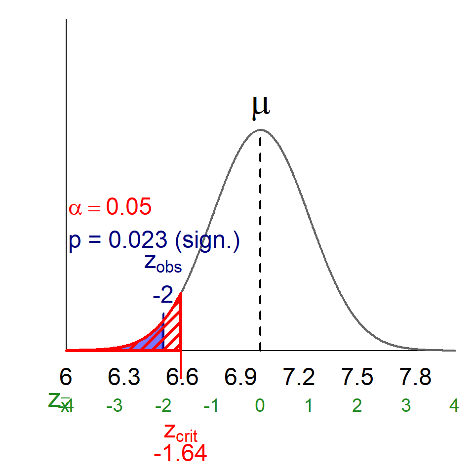

```r
#Visualizing the lower-tail example
zvis(6.5, 7, 2, 64, "left")
```

```r
#Effect size
(6.5-7)/2
```

```
## [1] -0.25
```

# 11 Exercise 11

```r
#Standard error
(se <- 2/sqrt(64))
```

```
## [1] 0.25
```

```r
#z-value
(zscore <- ((6.5-7) / se))
```

```
## [1] -2
```

```r
#p-value
(pval <- pnorm(zval, lower.tail = T))
```

```
## [1] 0.9522096
```

```r
#critical value
qnorm(p=0.01, mean=7, sd=se)
```

```
## [1] 6.418413
```

Since 6.5 is higher than 6.418413, we do not reject our null hypothesis, because it is not a significant result now.

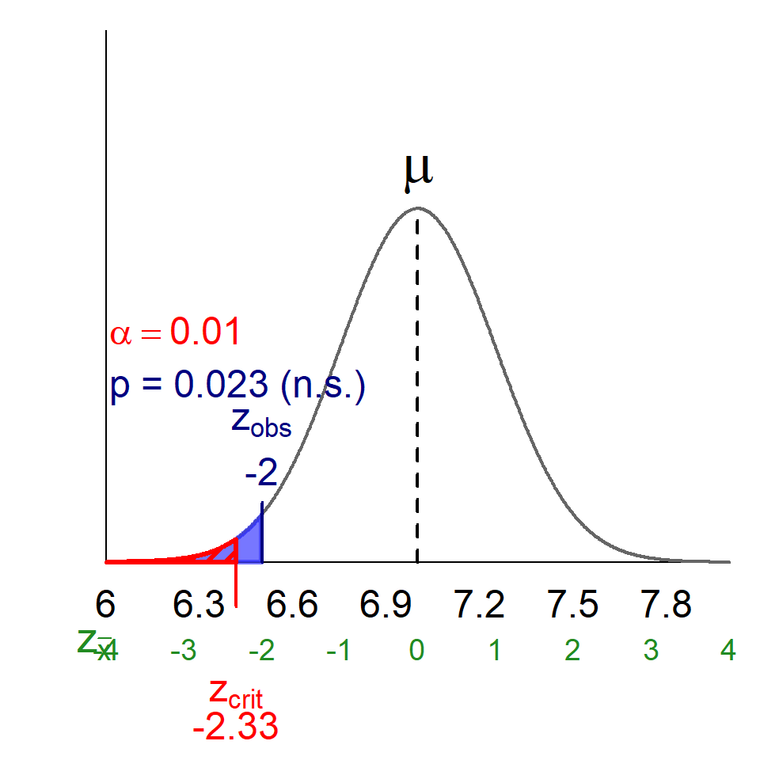

```r
#Visualizing the lower-tail example
zvis(6.5, 7, 2, 64, "left", alpha=0.01)
```

```r
#Effect size
(6.5-7)/2
```

```
## [1] -0.25
```